# Text mining

## Представление текста в данных

Задачи text mining обычно имеют дело с большим количеством фрагментов текста, например: твиты, новости, отзывы и т.п. Собрав такие данные, мы чаще всего получаем таблицу, одна из колонок которой содержит эти тексты, по одному на строку. В остальных колонках содержатся *метаданные* об этих текстах — автор, название, дата и т.п.

Наш сегодняшний пример: коллекция из 10 произведений двух авторов — Фриды Вигдоровой и Любови Воронковой, которые писали прозу для подростков в 1940-е — 1950-е годы. Произведения довольно длинные, поэтому для удобства работы они разбиты на фрагменты длиной примерно в 400 слов.

```r
library(readr)
library(ggplot2)

vv = read.csv("~/shared/minor2_2018/2-tm-net/lab03-tm/vv.csv", stringsAsFactors=FALSE)
```

Тексты находятся в колонке text.

Мы хотим использовать текст как переменную, чтобы включить в наши модели. Но непонятно, как к текстовой переменной применить простые математические операции. Например, сравнение. Какой текст «больше» — в первой строке или в тринадцатой? А какие тексты ближе друг к другу — 1 и 2 или 2 и 3?

Вывод: нужно разложить текст на какие-то простые единицы, которые понятно, как считать и сравнивать.

Чаще всего удобно взять в качестве такой единицы *слово* и сделать каждое слово в тексте отдельной переменной.

Есть два способа представить разбитый на слова текст в виде таблицы:

- длинный формат — для каждого слова в тексте создается отдельная строка в данных;
- широкий формат — для каждого слова создается отдельная колонка в данных, текст — это одна строка.

Мы начнем с длинного формата, знакомого вам, например, по ggplot2. Для преобразования текста в этот формат используем пакет tidytext.

```r
library(dplyr)
library(tidytext)

vv.tidy = vv %>%
    unnest_tokens(words, text)
```

Токены — это единицы текста, в нашем случае — слова. В качестве токенов могут выступать буквы, предложения и т.п.

## Частотность

Теперь у нас в таблице есть колонка со словами. Это категориальная переменная, которая принимает столько значений, сколько есть разных слов в текстах.

```r
vv.tidy %>%
    dplyr::select(words) %>%
    n_distinct() # ого, их довольно много!
```

```
## [1] 51534
```

Мда, все значения не посмотришь. Но можно посмотреть самые частотные, наверное, они самые важные и интересные?

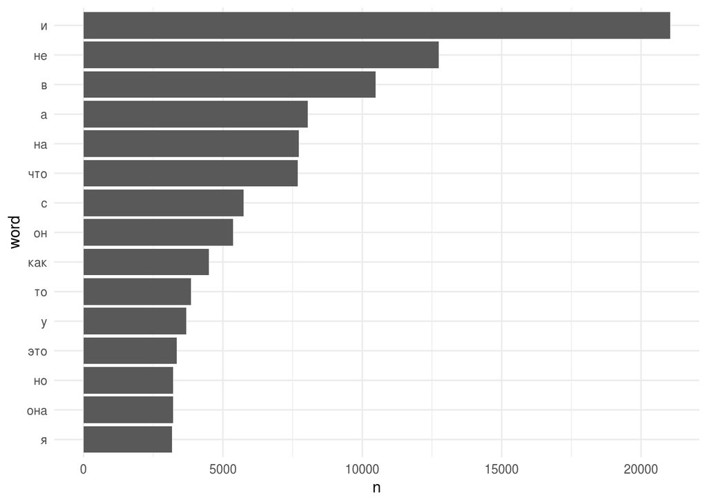

```r
vv.tidy %>%
    count(words, sort = TRUE) %>%
    top_n(15, n) %>%
    ggplot(aes(x = reorder(words, n), y = n)) +
    geom_col() +
    labs(x = "word") +
    coord_flip() +
    theme_minimal()
```

Не слишком информативно. Так, а как вообще выглядит распределение?

## Частотность языковых знаков. Закон Ципфа

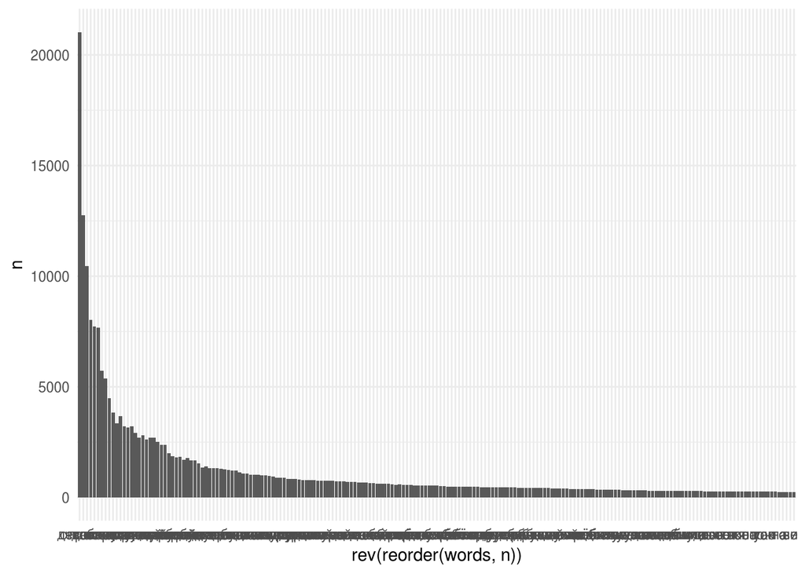

```r
vv.tidy %>%
    count(words, sort = TRUE) %>%
    filter(n > 250) %>%
    ggplot(aes(rev(reorder(words, n)), n)) +
    geom_bar(stat = "identity", show.legend = FALSE) +
    theme_minimal()
```

Распределение с длинным хвостом. Few giants, many dwarfs.

Более того, замечено, что для любого достаточно большого набора текстов распределение частотностей слов лог-линейно:

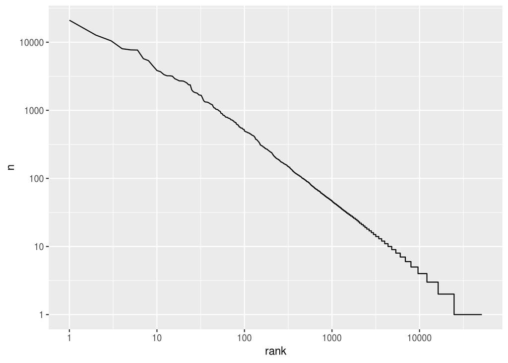

```r
vv.tidy %>%
    count(words, sort = TRUE) %>%
    mutate(rank = row_number()) %>%
    ggplot(aes(rank, n)) +
    geom_line() +
    scale_x_log10() +
    scale_y_log10()
```

Эта закономерность называется Законом Ципфа.

## Стоп-слова

Самые частотные слова в языке — предлоги, союзы, местоимения — имеют самые абстрактные значения. Если нас интересует содержание текста, они для нас неинформативны. Назовем их «стоп-слова» и попробуем выкинуть из текста.

В пакете stopwords уже есть заготовленный список стоп-слов для русского языка.

```r
library(stopwords)
head(stopwords("ru"), 20)
```

```
##  [1] "и"   "в"   "во"  "не"  "что" "он"  "на"  "я"   "с"   "со"  "как"
## [12] "а"   "то"  "все" "она" "так" "его" "но"  "да"  "ты"
```

Мы уже видели очень похожий список…

```r
top100words = vv.tidy %>%
    dplyr::count(words, sort=TRUE) %>%
    top_n(100, n)

top100words$words
```

```
##   [1] "и"       "не"      "в"       "а"       "на"      "что"     "с"
##   [8] "он"      "как"     "то"      "у"       "это"     "но"      "она"
##  [15] "я"       "все"     "к"       "так"     "вот"     "ты"      "же"
##  [22] "за"      "его"     "по"      "из"      "да"      "мы"      "мне"
##  [29] "было"    "ну"      "только"  "бы"      "они"     "от"      "о"
##  [36] "меня"    "когда"   "еще"     "нет"     "сказал"  "если"    "вы"
##  [43] "уже"     "сказала" "надо"    "ее"      "очень"   "ни"      "тут"
##  [50] "ему"     "кто"     "их"      "был"     "ребята"  "может"   "нас"
##  [57] "ведь"    "него"    "всё"     "ли"      "ей"      "тоже"    "до"
##  [64] "сейчас"  "ничего"  "потом"   "там"     "со"      "будет"   "почему"
##  [71] "раз"     "глаза"   "тебе"    "для"     "где"     "чтобы"   "или"
##  [78] "тебя"    "даже"    "теперь"  "уж"      "нибудь"  "вдруг"   "хорошо"
##  [85] "чем"     "есть"    "под"     "была"    "больше"  "без"     "её"
##  [92] "день"    "чего"    "нам"     "себя"    "быть"    "говорит" "снова"
##  [99] "человек" "всех"
```

```r
head(top100words, 20)
```

```
## # A tibble: 20 x 2
##    words     n
##    <chr> <int>
##  1 и     21037
##  2 не    12742
##  3 в     10471
##  4 а      8035
##  5 на     7727
##  6 что    7679
##  7 с      5736
##  8 он     5369
##  9 как    4488
## 10 то     3844
## 11 у      3687
## 12 это    3350
## 13 но     3218
## 14 она    3215
## 15 я      3175
## 16 все    2912
## 17 к      2811
## 18 так    2707
## 19 вот    2703
## 20 ты     2690
```

Выбросим из текстов стоп-слова и посмотрим, что осталось.

```r
rustopwords = data.frame(words=stopwords("ru"), stringsAsFactors=FALSE)
vv.nonstop = vv.tidy %>%
    anti_join(rustopwords)
#filter(!(words %in% stopwords("ru")))
```

На сколько процентов уменьшился объем текста?

## Облако слов

Теперь построим список самых частотных слов в форме облака слов.

```r
library(wordcloud2)

vv.nonstop.counts = vv.nonstop %>%
    count(words, sort=TRUE) %>%
    top_n(50, n)

wordcloud2(data = vv.nonstop.counts)
```

[interactive chart not shown]

```r
wordcloud2(data = vv.nonstop.counts, color = "black", rotateRatio = 0)
```

[interactive chart not shown]

Различаются ли тексты двух писательниц?

Добавим в данные переменные «автор» и «книга»:

```r
library(stringr)

vv = vv %>%
    mutate(author = str_extract(title, '[^.]+')) %>%
    mutate(book = str_extract(title, '[^.]+[.][^.]+'))

vv.tidy = vv %>%
    unnest_tokens(words, text)
```

**Ваша очередь**

1. Постройте частотные списки для текстов каждой из двух писательниц, выведите облака слов. Используйте список стоп-слов из пакета stopwords.
2. Используйте в качестве списка стоп-слов те слова, которые встретились в общем списке слов более 150 раз.
3. (*) Постройте график закона Ципфа для каждой книги по-отдельности. Подсказка: пример есть в [книге о tidyverse](https://www.tidytextmining.com/tfidf.html#zipfs-law).

Что вы можете сказать? Отличаются ли облака?

## Стилометрия

Правда ли, что стоп-слова совсем не информативны и их всегда нужно выкидывать?

Посмотрим на разницу в употреблении личных местоимений:

```r
pers.pronouns = c("я", "меня", "мне",
                   "мы", "нас", "нам",
                   "ты", "тебя", "тебе",
                   "вы", "вас", "вам",
                   "он", "его", "него", "ему", "нем",
                   "она", "ее", "нее", "ей", "ней",
                   "они", "их", "них", "им", "ним", "ими", "ними")
pronouns.df = data.frame(words = pers.pronouns, stringsAsFactors = FALSE)
pron.count = vv.tidy %>%
    inner_join(pronouns.df) %>%
    group_by(author) %>%
    dplyr::count(words, sort=TRUE)
```

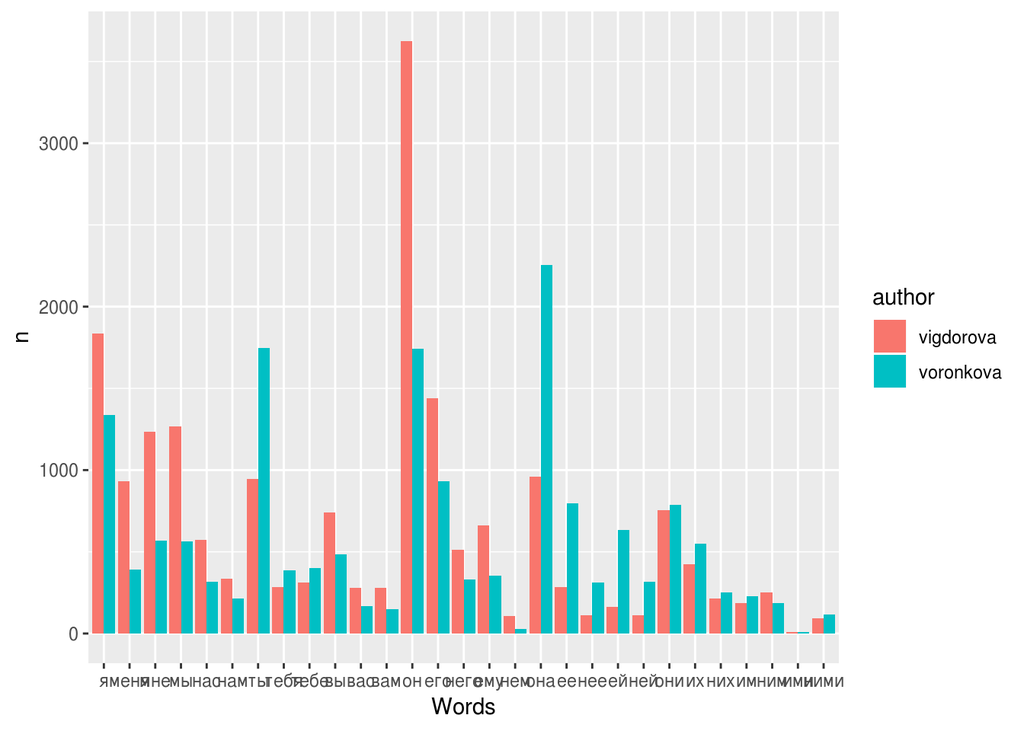

```r
ggplot(data = pron.count) +
  geom_bar(aes(x=words, y = n, fill = author), stat = "identity", position = "dodge") +
  scale_x_discrete(name ="Words",  limits=pers.pronouns)
```

## Широкий формат

Длинный формат представления текстов удобен для подсчета частотностей и для интеграции с инструментами tidyverse. Но если мы хотим использовать тексты, например, для машинного обучения, нам нужно, чтобы каждому тексту соответствовал набор переменных, характеризующих его содержание.

Широкий формат представления текстов используется так широко, что имеет собственное название — *матрица документов-термов*. Каждая строка матрицы — текст, каждому возможному слову соответствует колонка, а в качестве значения используется частотность слова в данном тексте.

В пакете tidyverse есть набор функций cast_* для преобразования длинного формата в широкий.

Оставим только стоп-слова:

```r
vv.stop = vv.tidy %>%
    inner_join(rustopwords)
```

Построим матрицу документов-термов для нескольких самых частотных слов в наших книгах:

```r
books.dtm = vv.stop %>%
    group_by(book) %>%
    dplyr::count(words, sort = TRUE) %>%
    cast_sparse(book, words, n)
```

Используем для стилометрии. Чтобы нарисовать на двумерном графике представление по осям, соответствующим всем нашим местоимениям, будем использовать анализ главных компонент (“собирать” оси в более крупные компоненты)

```r
pron.dtm = vv.tidy %>%
    inner_join(pronouns.df) %>%
    group_by(book) %>%
    dplyr::count(words, sort=TRUE) %>%
    cast_sparse(book, words, n)
```

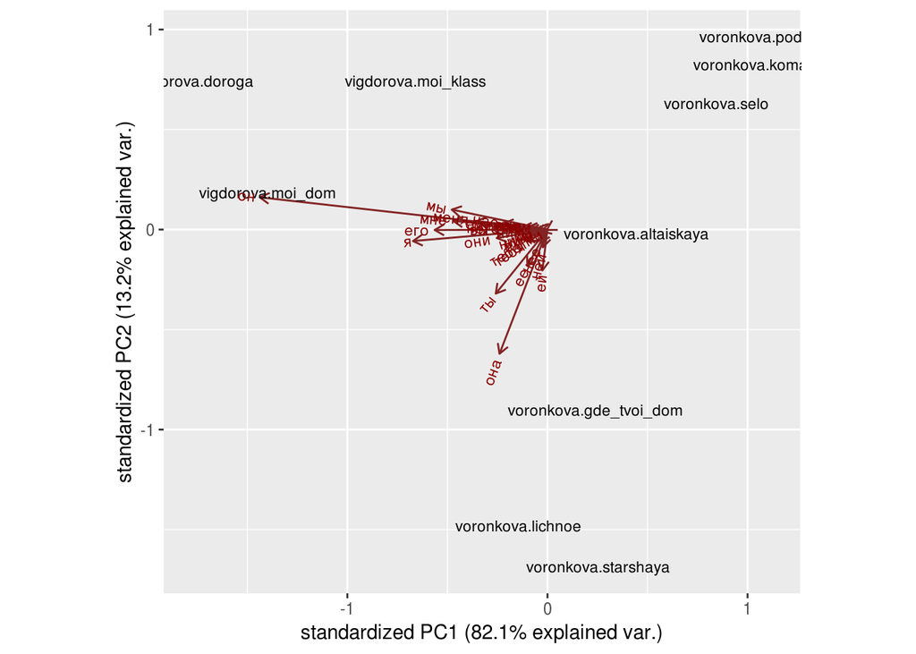

```r
pron.pca = prcomp(pron.dtm)
ggbiplot::ggbiplot(pron.pca, labels = rownames(pron.dtm))
```

## Автоматический анализ содержания текста

Таким образом по частотному распределению самых распространенных слов можно автоматически различать стиль разных авторов. Если же рассмотреть частотное распределение знаменательных слов (прежде всего — существительных), можно автоматически различать тексты разной тематики.

## Векторное представление документов

Мы с ним уже встречались: это то же самое, что и данные в широком формате, и то же самое, что и матрица термов-документов. Каждый документ можно представить как вектор в многомерном пространстве.

```r
text1 = c("я" = 1, "облака" = 1, "фиолетовая" = 1, "вата" = 1,
          "розовые" = 0, "мечтал" = 0, "долго" = 0,
          "прости" = 0, "малая" = 0, "мне" = 0, "надоело" = 0)

text2 = c("я" = 1, "облака" = 1, "фиолетовая" = 0, "вата" = 0,
          "розовые" = 1, "мечтал" = 1, "долго" = 1,
          "прости" = 0, "малая" = 0, "мне" = 0, "надоело" = 0)

text3 = c("я" = 1, "облака" = 0, "фиолетовая" = 0, "вата" = 0,
          "розовые" = 0, "мечтал" = 0, "долго" = 0,
          "прости" = 1, "малая" = 1, "мне" = 1, "надоело" = 1)

test_tdm = rbind(text1, text2, text3) # матрица термов-документов
```

Теперь мы можем сравнить не только отдельные слова, но и тексты, сравнив соответствующие им вектора. В качестве меры близости мы будем использовать косинус угла между векторами.

```r
lsa::cosine(text1, text2)
```

```
##           [,1]
## [1,] 0.4472136
```

Какая пара текстов похожа больше всего?

```r
lsa::cosine(t(test_tdm))
```

```
##           text1     text2     text3
## text1 1.0000000 0.4472136 0.2236068
## text2 0.4472136 1.0000000 0.2000000
## text3 0.2236068 0.2000000 1.0000000
```

## Нормализованная частотность. TF-IDF

Для анализа документов по содержанию не все слова одинаково полезны. Самые бесполезные — те, которые встречаются слишком часто (вне зависимости от тематики) и hapax legomena. Для различения документов полезнее всего слова из середины частотного распределения. Чтобы повысить вес таких слов и понизить вес остальных, придумали взвешенную частотность — TF-IDF.

- TF — term frequency (частота слова в документе)
- IDF — inverse documemnt frequency (обратная документная частота: логарифм отношения количества документов в коллекции к числу документов, в которых встречается данное слово)

Сейчас мы научимся считать эту метрику на текстах из датасета с реальными отзывами на отели Санкт-Петербурга с сайта TripAdviser!

## Подготовка данных

Прежде чем приступать к анализу, нам нужно подготовить векторное представление документов.

Загрузим данные и токенизируем тексты отзывов к отелям Санкт-Петербурга. Преобразуем их в длинный формат.

**Лемматизация** Если мы интересуемся содержанием, нам нужно считать разные формы слова одной и той же единицей. Для этого применяется лемматизация — автоматическое приведение слова к начальной форме. Мы провели эту операцию над текстами заранее с помощью программы [mystem](https://tech.yandex.ru/mystem/).

```r
reviews = read_csv("~/shared/minor2_2018/2-tm-net/lab03-tm/reviews.csv")
# в колонке lem лемматизированные отзывы + нет пунктуации и чисел

reviews.tidy = reviews %>%
  select(id, lem) %>%
  unnest_tokens(words, lem)
```

Удалим стоп-слова, а также слишком редкие слова по порогу.

```r
rustopwords = data.frame(words=stopwords::stopwords("ru"), stringsAsFactors=FALSE)
# словарь со стоп-словами

reviews.tidy = reviews.tidy %>%
  anti_join(rustopwords)
```

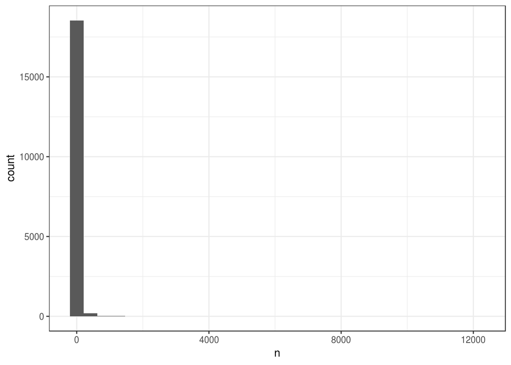

```r
words_count = reviews.tidy %>%
  dplyr::count(words)

words_count %>%
  ggplot() +
  geom_histogram(aes(x = n)) +
  theme_bw()
```

```r
#сколько слов встречается в текстах всего один раз?
quantile(words_count$n, 0.55)
```

```
## 55%
##   1
```

```r
quantile(words_count$n, 0.65)
```

```
## 65%
##   2
```

```r
#удалим слишком редкие и наоборот, слишком распространенные
words_count = words_count %>%
  filter(n > 5 & n < quantile(words_count$n, 0.95))

reviews.tidy = reviews.tidy %>%
  filter(words %in% words_count$words)
```

После всей чистки у нас осталось сильно меньше слов, чем было изначально. Поэтому от некоторых отзывов могло или совсем ничего или пара слов. Уберем такие отзывы из базы для дальнейшего анализа.

```r
# удалить отзывы от которых осталось мало слов
reviews_count = reviews.tidy %>%
    dplyr::count(id) %>%
    filter(n > 5)

# для оставшихся отзывов посчитаем метрику TF-IDF
reviews_tf_idf = reviews.tidy %>%
    filter(id %in% reviews_count$id) %>%
    dplyr::count(id, words) %>%
    bind_tf_idf(words, id, n)

# приведем данные к широкому формату. создадим term-document matrix
library(tidyr)
reviews.tdm = reviews_tf_idf %>%
    dplyr::select(id, words, tf_idf) %>%
    spread(words, tf_idf, fill = 0)
```

Посчитаем косинусное расстояние между двумя векторами отзывов. Эти два текста наиболее похожи друг на друга.

```r
#посмотреть сами тексты отзывов
reviews$review[reviews$id == "rn308356496"]
```

```
## [1] "\nРекомендую! Вежливый персонал, чистые, большие, уютные и красивые номера. Вкусная еда, круглосуточная работа ресторана. Удобное месторасположение, буквально в 5 минутах от Невского и Московского вокзала. Рядом метро, кафе и ТЦ.\nРаньше останавливались в Park Inn by Radisson.\n"
## [2] "\nРекомендую! Вежливый персонал, чистые, большие, уютные и красивые номера. Вкусная еда, круглосуточная работа ресторана. Удобное месторасположение, буквально в 5 минутах от Невского и Московского вокзала. Рядом метро, кафе и ТЦ.\nРаньше останавливались в Park Inn by Radisson.\n"
```

```r
reviews$review[reviews$id == "rn249258173"]
```

[output not shown]

```r
review1 = reviews.tdm %>%
    filter(id == "rn308356496") %>%
    dplyr::select(-id) %>%
    as.numeric()

review2 = reviews.tdm %>%
    filter(id == "rn249258173") %>%
    dplyr::select(-id) %>%
    as.numeric()

lsa::cosine(review1, review2)
```

```
##           [,1]
## [1,] 0.6966298
```

**Ваша очередь:**

Давайте попробуем еще раз. Загрузите датасет, в котором содержатся посты из пабликов “Медиазона” и “Комсомольская правда”.

```r
library(readr)
media = read_csv("~/shared/minor2_2018/2-tm-net/lab03-tm/media.csv")
pers.pronouns = c("они", "мы", "он", "она", "я", "вы")
pronouns.df = data.frame(words = pers.pronouns, stringsAsFactors = FALSE)
```

1. Посмотрите, как отличается использование некоторых местоимений в этих постах. Есть ли разница в использовании местоимений?
2. С помощью косинусных расстояний оцените, насколько отличаются тексты по содержанию. Найдите несколько примеров сильно похожих и отличающихся текстов.